# Protocol 3

Joachim Goedhart

2021-12-16

## Protocol 3 - small mutliples of time courses

This protocol displays a number of different timecourses as ‘small multiples’. Small multiples, as the name suggests, displays many small plot separately as a stamp collection. By stressing the data, rather than the labels and grids, this can be a powerful visualization strategy.

The data is taken from a publication by [Arts et al. (2021)](https://doi.org/10.3389/fimmu.2021.667213) and we recreate figure panel 1F. The original figure is in small multiple format, but we tweak it a bit more to increase the focus on the data.

Let’s first load the necessary package:

```r
library(tidyverse)
```

The data comes from an excel file:

```r
df <- readxl::read_excel("Data_Arts_Circularity.xlsx")
head(df)
```

```
## # A tibble: 6 x 13
##    time `neutro 1` `neutro 2` `neutro 3` `neutro 4` `neutro 5` `neutro 6` `neutro 7` `neutro 8` `neutro 9`
##   <dbl>      <dbl>      <dbl>      <dbl>      <dbl>      <dbl>      <dbl>      <dbl>      <dbl>      <dbl>
## 1     0       0.53       0.54       0.55       0.59       0.58       0.34       0.38       0.52       0.66
## 2    10       0.44       0.6        0.5        0.4        0.54       0.4        0.37       0.43       0.66
## 3    20       0.33       0.55       0.64       0.3        0.48       0.41       0.43       0.46       0.58
## 4    30       0.35       0.54       0.69       0.28       0.52       0.32       0.48       0.3        0.51
## 5    40       0.41       0.53       0.57       0.23       0.44       0.29       0.39       0.28       0.39
## 6    50       0.32       0.4        0.4        0.26       0.43       0.25       0.34       0.32       0.28
## # … with 3 more variables: neutro 10 <dbl>, neutro 11 <dbl>, neutro 12 <dbl>
```

It is in a wide format, so we need to make it tidy. The parameter that was measured over time is the ‘roundness’ of cells:

```r
df_tidy <-
  pivot_longer(
    df,
    cols = -time,
    names_to = "Cell",
    values_to = "Roundness"
  )
```

First we create a line plot of all the data:

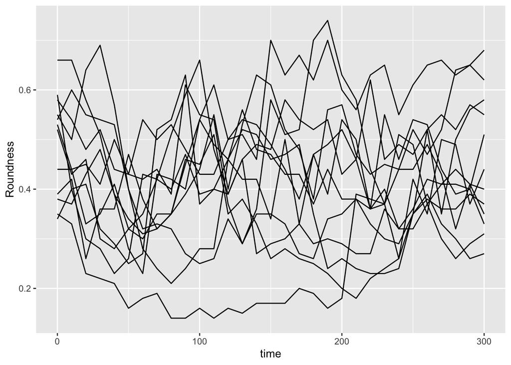

```r
p <- ggplot(df_tidy, aes(x=time, y=Roundness, group=Cell)) + geom_line()
p
```

With the facet_wrap() function, we turn this into a small multiple:

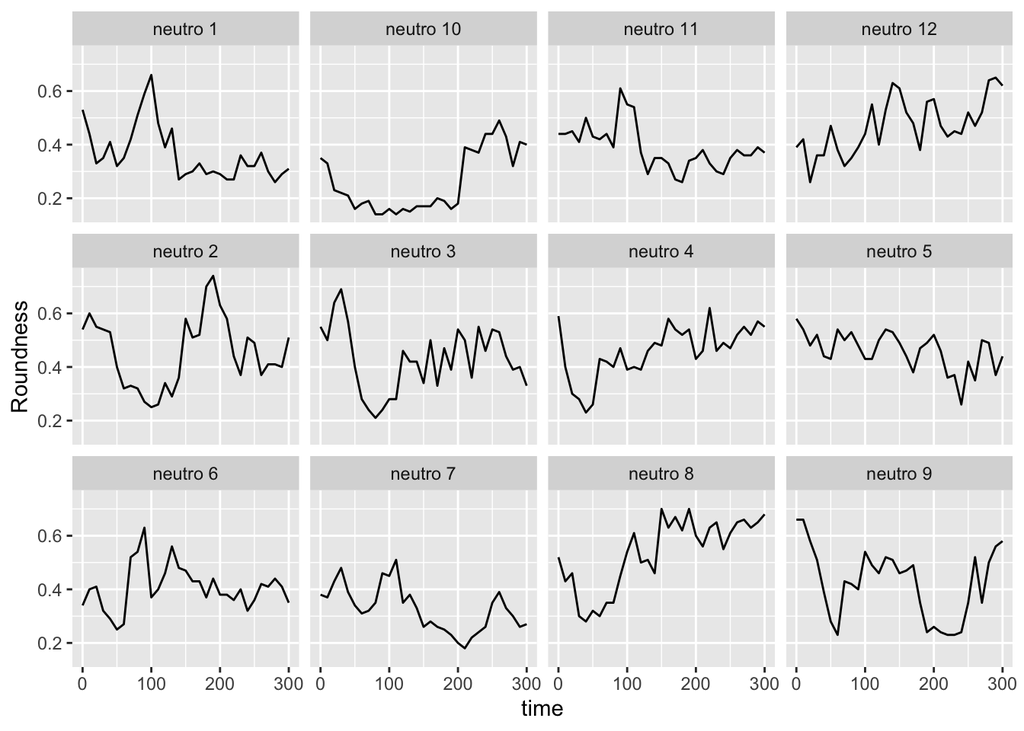

```r
p <- p + facet_wrap(~Cell)
p
```

Set the limits of the axis and force the y-axis to start at 0

```r
p <-
  p + scale_y_continuous(expand = c(0, 0), limits = c(0, 1.0)) +
  scale_x_continuous(expand = c(0,0), limits = c(0, 300))
```

Use a minimal theme and remove the strips and grid to increase focus on the data:

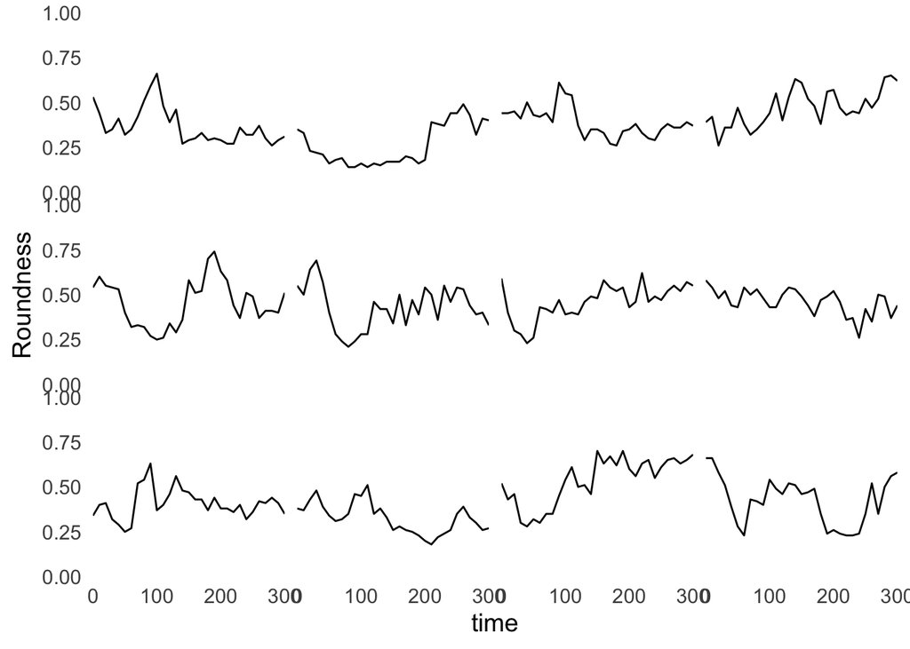

```r
p <- p + theme_minimal(base_size = 14)

p <- p + theme(strip.background = element_blank(),
               strip.text = element_blank(),
               plot.caption = element_text(color = "grey80"),
               #Remove grid
               panel.grid.major = element_blank(),
               panel.grid.minor = element_blank()
)
p
```

I do not like the repeated axis for the different plots. We can remove those:

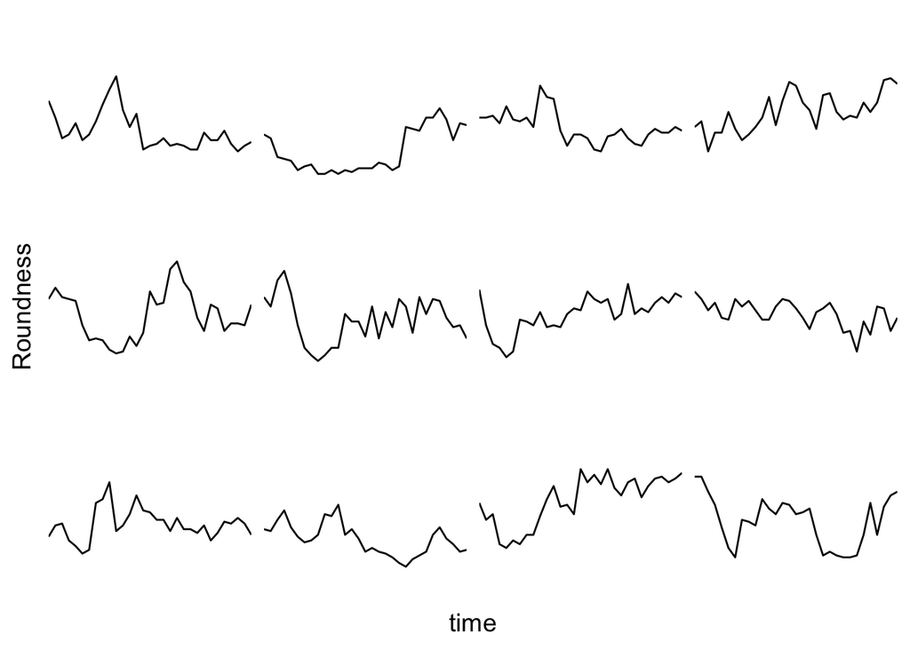

```r
p <- p + theme(
        #Remove axis labels
        axis.text = element_blank()
        )
p
```

This is a very minimal plot, focusing entirely on the data. It may work well, but it is informative to add some information about the scaling of the x- and y-axis. To achieve this, I add lines to the lower left plot, which correspond to the data of ‘neutro 6’ (you can see this in the small multiple plot where each plot was labeled). I define a new dataframe with the x- and y-scale for ‘neutro 6’ to do just that:

```r
ann_line<-data.frame(xmin=0,xmax=300,ymin=0,ymax=1,
                     Cell=factor("neutro 6",levels=c("neutro 6")))
ann_line
```

```
##   xmin xmax ymin ymax     Cell
## 1    0  300    0    1 neutro 6
```

This dataframe can now be used to draw two lines with `geom_segment()`:

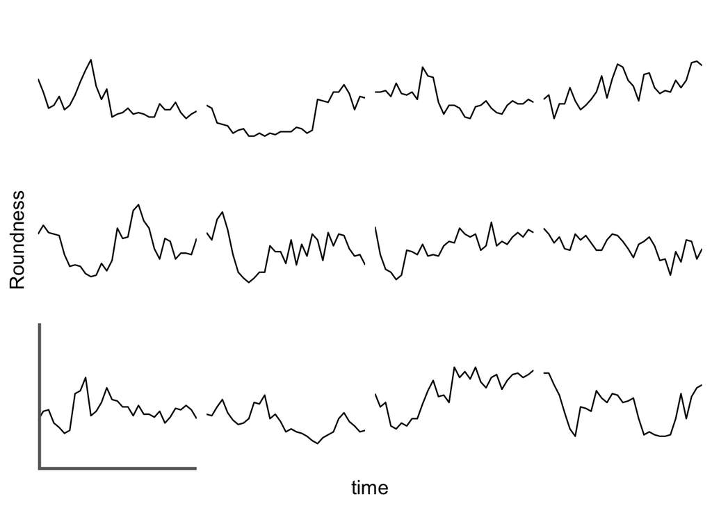

```r
p <- p +
  #Vertical line
  geom_segment(data=ann_line, aes(x=xmin,xend=xmin,y=ymin,yend=ymax), size=2, color='grey40') +
  #Horizontal line
  geom_segment(data=ann_line, aes(x=xmin,xend=xmax,y=ymin,yend=ymin), size=2, color='grey40') +
  NULL

p
```

The plot is now in black and white which gives it a strong contrast. We can make it a bit more soft and pleasant to look at by changing to shades of grey. Also, the labels of the axes are moved next to the lines:

```r
p <- p +
  theme(panel.background = element_rect(fill='grey98', color=NA),
        panel.border = element_rect(color='grey90', fill=NA),
        axis.title.x = element_text(size=14, hjust = 0, color='grey40'),
        axis.title.y = element_text(size=14, vjust = 0, hjust=0, angle = 90, color='grey40'),
  )
```

Finally, we add a title, caption, and labels (and a scale in brackets):

```r
p <-
  p + labs(
    title = "Changes in the shape of migrating cells over time",
    x = "Time [300s]",
    y = "Circularity [0-1]",
    caption = "(based on data from Arts et al., DOI: 10.3389/fimmu.2021.667213)",
    tag = "Protocol 3"
  )
```

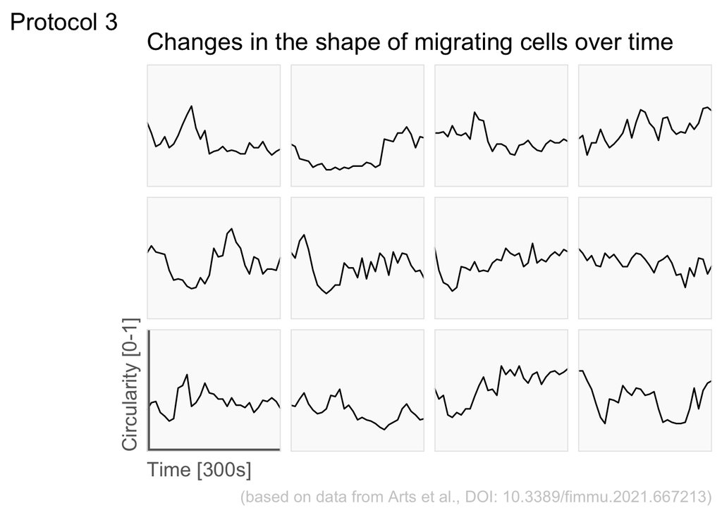

```r
p
```

```r
png(file=paste0("Protocol_3.png"), width = 4000, height = 3200, units = "px", res = 400)
 p
dev.off()
```